# Perceptron

### **Pseudocode**

Import required libraries

Generate random data

Initialize weights and bias

Perceptron training function:

- For each epoch in a range of epochs:
  - For each data point (x, y) and its label:
    - Calculate prediction. If the prediction is incorrect:Update weights and bias using the perceptron rule.

Calculate the Hinge loss to evaluate the performance

Draw points of both classes on the graph

Drawing the decision line using the weights and bias

Display the graph

Function to calculate the Hinge loss:

Function hinge_loss(data_x, data_y, labels, weights, bias):

- Initialize loss to 0.
  - For each data point (x, y) and its label:
    - Calculate the prediction. Add Hinge loss to total

Function for updating weights and bias:

Function sgd_optimization(weights, bias, x, y, label, learning_rate):

- Calculate prediction.
  - If prediction is incorrect:
    - Update weights and bias using the perceptron rule. Return new weights and bias

Calculate Hinge loss to evaluate performance

Plot the points of both classes

Draw the decision line

Display the graph

```
Hinge Loss: 100.00
```

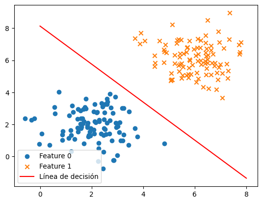

```python
import numpy as np
import matplotlib.pyplot as plt

# Random data
n_points = 100
class1_x = np.random.normal(2, 1, n_points)
class1_y = np.random.normal(2, 1, n_points)
class2_x = np.random.normal(6, 1, n_points)
class2_y = np.random.normal(6, 1, n_points)
data_x = np.concatenate((class1_x, class2_x))
data_y = np.concatenate((class1_y, class2_y))
labels = np.array([0] * n_points + [1] * n_points)

# Initialization of weights and bias
weights = np.random.rand(2)
bias = np.random.rand()
learning_rate = 0.1

# Perceptron training function
def perceptron_train(data_x, data_y, labels, weights, bias, epochs, learning_rate):
    for epoch in range(epochs):
        for x, y, label in zip(data_x, data_y, labels):
            prediction = np.dot(np.array([x, y]), weights) + bias
            if prediction > 0 and label == 0:
                weights -= learning_rate * np.array([x, y])
                bias -= learning_rate
            elif prediction < 0 and label == 1:
                weights += learning_rate * np.array([x, y])
                bias += learning_rate
    return weights, bias

# Loss Function (Hinge Loss)
def hinge_loss(data_x, data_y, labels, weights, bias):
    loss = 0
    for x, y, label in zip(data_x, data_y, labels):
        prediction = np.dot(np.array([x, y]), weights) + bias
        loss += max(0, 1 - label * prediction)
    return loss

# Implementación de Stochastic Gradient Descent (SGD)
def sgd_optimization(weights, bias, x, y, label, learning_rate):
    prediction = np.dot(np.array([x, y]), weights) + bias
    if prediction > 0 and label == 0:
        weights -= learning_rate * np.array([x, y])
        bias -= learning_rate
    elif prediction < 0 and label == 1:
        weights += learning_rate * np.array([x, y])
        bias += learning_rate
    return weights, bias

# Perceptron training function
trained_weights, trained_bias = perceptron_train(data_x, data_y, labels, weights, bias, epochs=100, learning_rate=learning_rate)

# Value of the Hinge Loss
hinge_loss_value = hinge_loss(data_x, data_y, labels, trained_weights, trained_bias)
print(f"Hinge Loss: {hinge_loss_value:.2f}")

# Create a plot for points of both classes
plt.scatter(class1_x, class1_y, marker='o', label='Feature 0')
plt.scatter(class2_x, class2_y, marker='x', label='Feature 1')

# Decision line
x_line = np.linspace(0, 8, 100)
y_line = (-trained_weights[0] / trained_weights[1]) * x_line - (trained_bias / trained_weights[1])
plt.plot(x_line, y_line, color='red', label='Línea de decisión')


plt.legend()

# Show plot
plt.show()
```

### **Loss Function**

The Hinge Loss function, which is a loss function commonly used for binary classification problems, is used. The Hinge Loss measures the distance between the model predictions and the actual labels. This loss function measures the distance between the decision plane (defined by the weights and bias) and the data points.